# Feature (model) selection (STAT5003 2018)

Pengyi Yang

17 September, 2018

## Libraries to load

```r
# library(limma)
library(gplots)
library(class)
```

## Feature selection and classification on Sonar dataset

This is the data set used by Gorman and Sejnowski in their study of the classification of sonar signals using a neural network [1]. The task is to train a network to discriminate between sonar signals bounced off a metal cylinder and those bounced off a roughly cylindrical rock. Each pattern is a set of 60 numbers in the range 0.0 to 1.0. Each number represents the energy within a particular frequency band, integrated over a certain period of time. The integration aperture for higher frequencies occur later in time, since these frequencies are transmitted later during the chirp. The label associated with each record contains the letter “R” if the object is a rock and “M” if it is a mine (metal cylinder). The numbers in the labels are in increasing order of aspect angle, but they do not encode the angle directly.

References Gorman, R. P., and Sejnowski, T. J. (1988). “Analysis of Hidden Units in a Layered Network Trained to Classify Sonar Targets” in Neural Networks, Vol. 1, pp. 75-89.

Newman, D.J. & Hettich, S. & Blake, C.L. & Merz, C.J. (1998). UCI Repository of machine learning databases [http://www.ics.uci.edu/~mlearn/MLRepository.html]. Irvine, CA: University of California, Department of Information and Computer Science.

```r
# load data
library(mlbench)
data(Sonar)
dim(Sonar)
```

```
## [1] 208  61
```

### partition the data into training and testing sets

```r
library(caret)
set.seed(123)
inTrain <- createDataPartition(Sonar$Class, p = .5)[[1]]
SonarTrain <- Sonar[ inTrain,]
SonarTest  <- Sonar[-inTrain,]
```

### Filter feature selection

#### Simple approach: fold change

```r
SonarTrain.byClass <- split(SonarTrain[,-61], SonarTrain$Class)
feature.mean.byClass <- sapply(SonarTrain.byClass, colMeans)

# calculate fold change of features by class and take the absolute of its log value
feature.foldChange <- abs(log2(feature.mean.byClass[,1] / feature.mean.byClass[,2]))

# sort the features by fold change
feature.sorted <- sort(feature.foldChange, decreasing=TRUE)

# select the top 10 features
filtered.features1 <- names(feature.sorted)[1:10]
filtered.features1
```

```
##  [1] "V46" "V12" "V45" "V11" "V47" "V51" "V36" "V13" "V10" "V52"
```

```r
# fitting the classifier on full expression dataset
knn.full <- knn(train=SonarTrain[,-61], test=SonarTest[,-61], cl=SonarTrain$Class, k=5, prob=TRUE)
table(knn.full, SonarTest$Class)
```

```
##
## knn.full  M  R
##        M 40 23
##        R 15 25
```

```r
# fitting the classifier on top 10 filtered features
knn.filtered <- knn(train=SonarTrain[,filtered.features1], test=SonarTest[,filtered.features1], cl=SonarTrain$Class, k=5, prob=TRUE)
table(knn.filtered, SonarTest$Class)
```

```
##
## knn.filtered  M  R
##            M 44 19
##            R 11 29
```

#### More sophisticated approach based on t-test

```r
SonarTrain.byClass <- split(SonarTrain[,-61], SonarTrain$Class)

# perform a t-test
feature.pvalues <- c()
for(i in 1:(ncol(SonarTrain)-1)) {
  feature.pvalues <- c(feature.pvalues, t.test(SonarTrain.byClass[[1]][,i], SonarTrain.byClass[[2]][,i])$p.value)
}
names(feature.pvalues) <- colnames(SonarTrain[,-61])

# filter the top 10 most discriminative features based on p-values
filtered.features2 <- names(sort(feature.pvalues)[1:10])

# fitting the classifier on full expression dataset
knn.full <- knn(train=SonarTrain[,-61], test=SonarTest[,-61], cl=SonarTrain$Class, k=5, prob=TRUE)
table(knn.full, SonarTest$Class)
```

```
##
## knn.full  M  R
##        M 40 23
##        R 15 25
```

```r
# fitting the classifier using top 10 filtered features by fold change
knn.filtered <- knn(train=SonarTrain[,filtered.features1], test=SonarTest[,filtered.features1], cl=SonarTrain$Class, k=5, prob=TRUE)
table(knn.filtered, SonarTest$Class)
```

```
##
## knn.filtered  M  R
##            M 44 19
##            R 11 29
```

```r
# fitting the classifier on top 10 filtered features by moderated t-test
knn.filtered <- knn(train=SonarTrain[,filtered.features2], test=SonarTest[,filtered.features2], cl=SonarTrain$Class, k=5, prob=TRUE)
table(knn.filtered, SonarTest$Class)
```

```
##
## knn.filtered  M  R
##            M 46 21
##            R  9 27
```

#### Visualise the features selected by filtering step using clustered “heatmap”

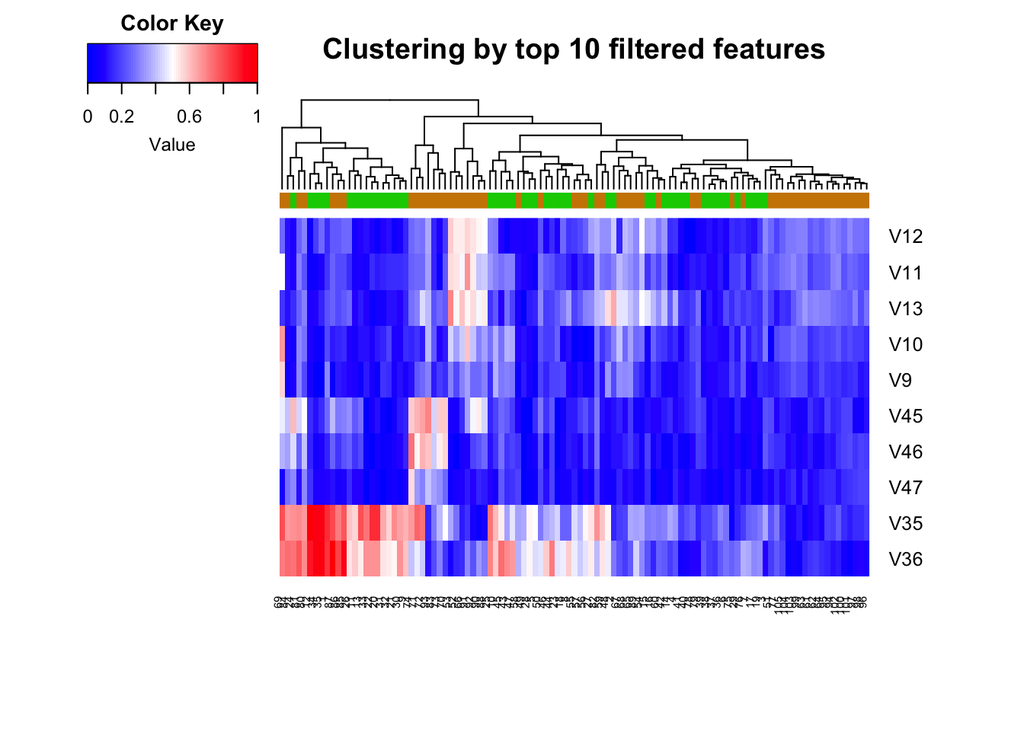

```r
library(gplots)
classcolors <- sapply(as.character(SonarTrain$Class), switch, R = "green3", M = "orange3")
SonarFiltered <- t(apply(SonarTrain[,filtered.features2], 2, as.numeric))

heatmap.2(SonarFiltered, col=bluered(75), ColSideColors=classcolors, density.info="none", trace="none", na.color = "black", margins=c(8, 8), main="Clustering by top 10 filtered features", dendrogram = "column")
```